# Climatology Quality Control

```r
data_fns <- list.files('data/filtered_data/', pattern = '.csv', full.names = TRUE)
test_21 <- readxl::read_xlsx("C:/users/ogradye/Documents/local_QC/extdata/qc_test_values.xlsx",
                                      sheet = 1)
test_22 <- readxl::read_xlsx("C:/users/ogradye/Documents/local_QC/extdata/qc_test_values.xlsx",
                                      sheet = 2)

for (i in 1:length(data_fns)) {

  data <- read.csv(data_fns[i])

  param_name <- unique(data$PARAMETER_NAME)
  if (param_name == 'Chlorophyll A') {
    param_name <- 'Chlorophyll'
  }
  if (param_name == 'Nitrate') {
    param_name <- 'Nitrate+Nitrite'
  }
  if (param_name == 'O2') {
    param_name <- 'Dissolved oxygen'
  }
  cat(param_name, '\n')

  # grab AZMP columns
  col_ind <- grep(names(test_21), pattern = 'AZMP')
  # check test 2.1 values
  if (!param_name %in% test_21$Variable){
    cat("Skipped: Variable not found in Test 2.1! ")
  } else{
    test_vals <- test_21 %>%
      select(c('Variable', all_of(col_ind))) %>%
      filter(Variable == param_name)

    min_col <- grep(names(test_vals), pattern = 'min', ignore.case = TRUE)
    max_col <- grep(names(test_vals), pattern = 'max', ignore.case = TRUE)

    if (is.na(test_vals[[min_col]]) | test_vals[[min_col]] == 'NA') {
      cat("Skipped: No global limits set! \n")
    } else{
    flag_data <- data %>%
      filter(DATA_VALUE < as.numeric(test_vals[[min_col]]) |
               DATA_VALUE > as.numeric(test_vals[[max_col]]))

    if (nrow(flag_data) > 0) {
      cat(nrow(flag_data), " points removed outside global range! \n")
    }

    if (nrow(flag_data) > 0) {
          data <- data[-which(data$X %in% flag_data$X),]
      }
    }
  }

  # Check Test 2.2 variables
    col_ind <- grep(names(test_22), pattern = 'AZMP')

  if (!param_name %in% test_22$Variable){
    cat("Skipped: Variable not found in Test 2.2! ")
  } else{
    test_vals <- test_22 %>%
      select(c('Variable', all_of(col_ind))) %>%
      filter(Variable == param_name)

    min_col <- grep(names(test_vals), pattern = 'min', ignore.case = TRUE)
    max_col <- grep(names(test_vals), pattern = 'max', ignore.case = TRUE)

    if (is.na(test_vals[[min_col]])| test_vals[[min_col]] == 'NA') {
      cat("Skipped: No regional limits set! \n")
    } else{
    flag_data <- data %>%
      filter(DATA_VALUE < as.numeric(test_vals[[min_col]]) |
               DATA_VALUE > as.numeric(test_vals[[max_col]]))

    if (nrow(flag_data) > 0) {
      cat(nrow(flag_data), " points removed outside regional range! \n")
    }

     if (nrow(flag_data) > 0) {
          data <- data[-which(data$X %in% flag_data$X),]
      }
    }


  }


 param_name <- unique(data$PARAMETER_NAME)

       write.csv(data,
                 file = paste0('data/filtered_data/SS_', param_name, '_test212_', Sys.Date(), '.csv'),
                 row.names = FALSE)

  cat('\n \n')

}
```

```
Ammonia
Skipped: No global limits set!
Skipped: No regional limits set!


Chlorophyll


Nitrate+Nitrite
3  points removed outside global range!


Nitrite


Dissolved oxygen


Phaeophytin
Skipped: No global limits set!
Skipped: No regional limits set!


Phosphate


Salinity
2  points removed outside global range!
2  points removed outside regional range!


Silicate
```

9. Check against IML Test 2.4 (profile envelope)

```r
data_fns <- list.files('data/filtered_data/', pattern = '.csv', full.names = TRUE)
test_24 <- readxl::read_xlsx("C:/users/ogradye/Documents/local_QC/extdata/qc_test_values.xlsx",
                                      sheet = 3)

for (i in 1:length(data_fns)) {

  data <- read.csv(data_fns[i])

  param_name <- unique(data$PARAMETER_NAME)
  if (param_name == 'Chlorophyll A') {
    param_name <- 'Chlorophyll'
  }
  if (param_name == 'Phaeophytin') {
    param_name <- 'Phaeo'
  }
  if (param_name == 'O2') {
    param_name <- 'Oxygen'
  }
  cat(param_name, '\n')

    test_vals <- test_24 %>%
      filter(Variable == param_name & Program == 'AZMP')
    if (nrow(test_vals) == 0) {
      cat("Skipped: No envelope range found! \n")
    } else{
      flag_data <- list()
      for (ii in 1:nrow(test_vals)) {
      flag_data[[ii]] <- data %>%
        filter(HEADER_START_DEPTH > test_vals$`Min Depth`[[ii]] &
                 HEADER_START_DEPTH < test_vals$`Max Depth`[[ii]]) %>%
        filter(DATA_VALUE < test_vals$`Min Value`[[ii]] |
                 DATA_VALUE > test_vals$`Max Value`[[ii]])
      }
      all_flag_data <- do.call(rbind, flag_data)

      if (nrow(all_flag_data) > 0) {
        cat(nrow(all_flag_data), " points outside profile envelope ranges! \n")
      }
    }


}
```

```
Ammonia
Skipped: No envelope range found!
Ammonia
Skipped: No envelope range found!
Chlorophyll
Nitrate
3  points outside profile envelope ranges!
Nitrite
Oxygen
1  points outside profile envelope ranges!
Phaeo
Skipped: No envelope range found!
Phosphate
Salinity
7  points outside profile envelope ranges!
Silicate
Chlorophyll
Nitrate
Nitrite
Oxygen
1  points outside profile envelope ranges!
Phaeo
Skipped: No envelope range found!
Phosphate
Salinity
5  points outside profile envelope ranges!
Silicate
```

Remove points outside of Test 2.4 limits and save new filtered data

```r
data_fns <- list.files('data/filtered_data/', pattern = '.csv', full.names = TRUE)


for (i in 1:length(data_fns)) {
  data <- read.csv(data_fns[i])

  param_name <- unique(data$PARAMETER_NAME)
  if (param_name == 'Chlorophyll A') {
    param_name <- 'Chlorophyll'
  }
  if (param_name == 'Phaeophytin') {
    param_name <- 'Phaeo'
  }
  if (param_name == 'O2') {
    param_name <- 'Oxygen'
  }
  cat(param_name, '\n')

    test_vals <- test_24 %>%
      filter(Variable == param_name & Program == 'AZMP')
    if (nrow(test_vals) == 0) {
      cat("Skipped: No envelope range found! \n")
      param_name <- unique(data$PARAMETER_NAME)

      t24filter_data <- data %>%
            select(-X)
      write.csv(t24filter_data,
                 file = paste0('data/filtered_data/SS_', param_name, '_test24_', Sys.Date(), '.csv'),
                 row.names = FALSE)

    } else{
      flag_data <- list()
      for (ii in 1:nrow(test_vals)) {
      flag_data[[ii]] <- data %>%
        filter(HEADER_START_DEPTH > test_vals$`Min Depth`[[ii]] &
                 HEADER_START_DEPTH < test_vals$`Max Depth`[[ii]]) %>%
        filter(DATA_VALUE < test_vals$`Min Value`[[ii]] |
                 DATA_VALUE > test_vals$`Max Value`[[ii]])
      }
      all_flag_data <- do.call(rbind, flag_data)

      if (nrow(all_flag_data) > 0) {
          t24filter_data <- data[-which(data$X %in% all_flag_data$X),] %>%
            select(-X)
          cat(nrow(all_flag_data), ' points removed! \n')

      } else {
        t24filter_data <- data %>%
            select(-X)
      }

       param_name <- unique(data$PARAMETER_NAME)

       write.csv(t24filter_data,
                 file = paste0('data/filtered_data/SS_', param_name, '_test24_', Sys.Date(), '.csv'),
                 row.names = FALSE)

    }


}
```

```
Ammonia
Skipped: No envelope range found!
Chlorophyll
Nitrate
Nitrite
Oxygen
1  points removed!
Phaeo
Skipped: No envelope range found!
Phosphate
Salinity
5  points removed!
Silicate
```

# Manual checks

Manually remove all data from CAR2021221 due to data loading issues (incorrect values were loaded to BioChem - brought to ODIS to be fixed)

```r
data_fns <- list.files('data/filtered_data/', pattern = '.csv', full.names = TRUE)


for (i in 1:length(data_fns)) {
  data <- read.csv(data_fns[i])
  param_name <- unique(data$PARAMETER_NAME)
  cat(param_name, '\n')
  if (length(which(data$NAME == 'CAR2021221') > 0)) {
    cat(nrow(data[data$NAME == 'CAR2021221',]))
    cat(' points removed from CAR2021221. \n')
  data <- data[-which(data$NAME == 'CAR2021221'),]
  }

  # remove bbmp2005
  if (length(which(data$NAME == 'BCD2005667') > 0)) {
    cat(nrow(data[data$NAME == 'BCD2005667',]))
    cat(' points removed from BCD2005667 \n')
  data <- data[-which(data$NAME == 'BCD2005667'),]
  }

  # remove HL02 2019 (salinty loaded as silicate)
  if (param_name == 'Salinity') {
    cat(nrow(data[data$NAME == 'BCD2019666',]))
    cat(' points removed from BCD2019666 \n')
    data <- data[-which(data$NAME == 'BCD2019666'),]
  }

  param_name <- unique(data$PARAMETER_NAME)
  data <- data %>%
    select(-grep(names(data), pattern = '^X'))


  write.csv(data,
                 file = paste0('data/filtered_data/SS_', param_name, '_final_', Sys.Date(), '.csv'),
                 row.names = FALSE)

}
```

```
Ammonia
Chlorophyll A
Nitrate
Nitrite
O2
Phaeophytin
Phosphate
Salinity
267 points removed from BCD2019666
Silicate
```

10. Outlier analysis

TODO

In generation of BBMP climatology (Reid Steele, 2023), outliers (outside IQR) were removed from data.

Compare data distribution after QC

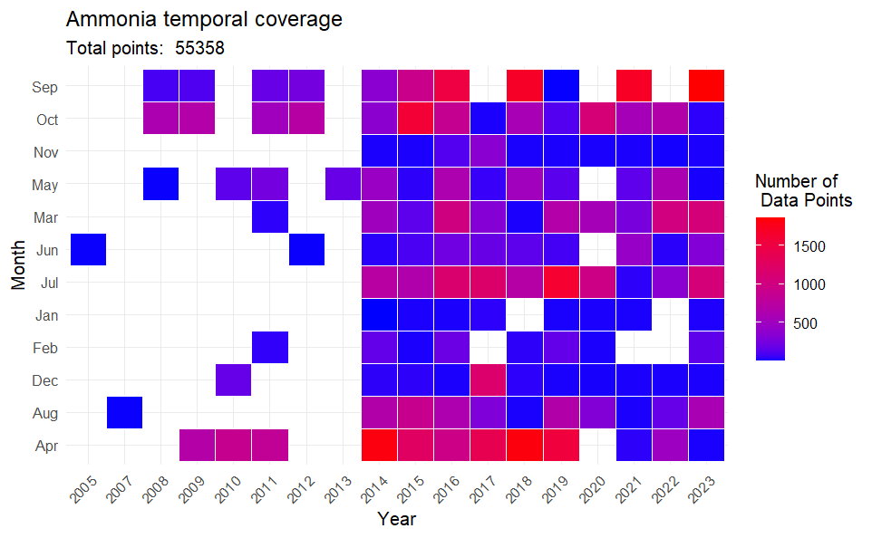

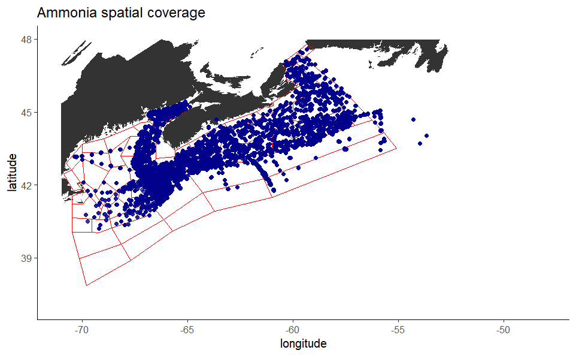

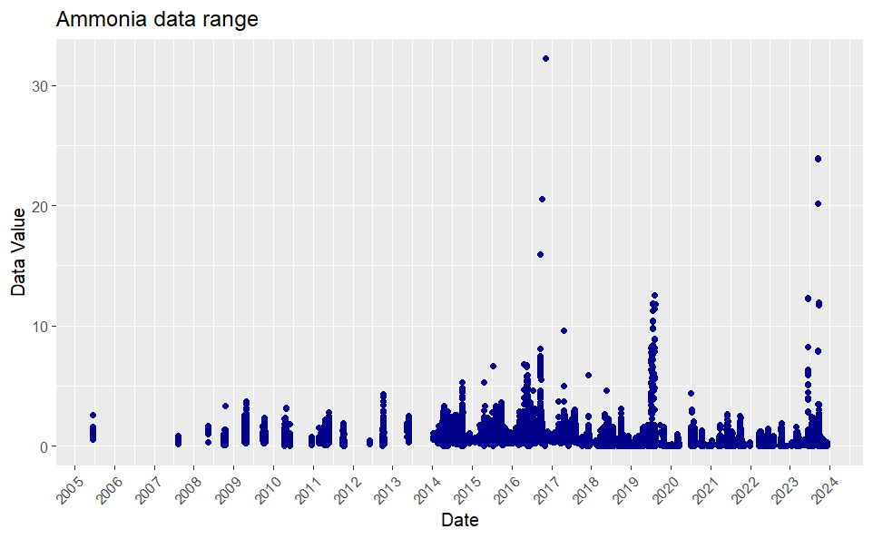

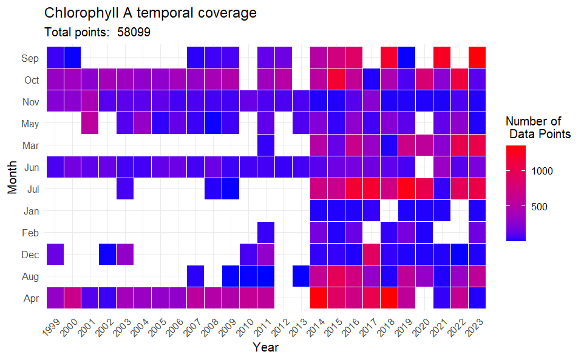

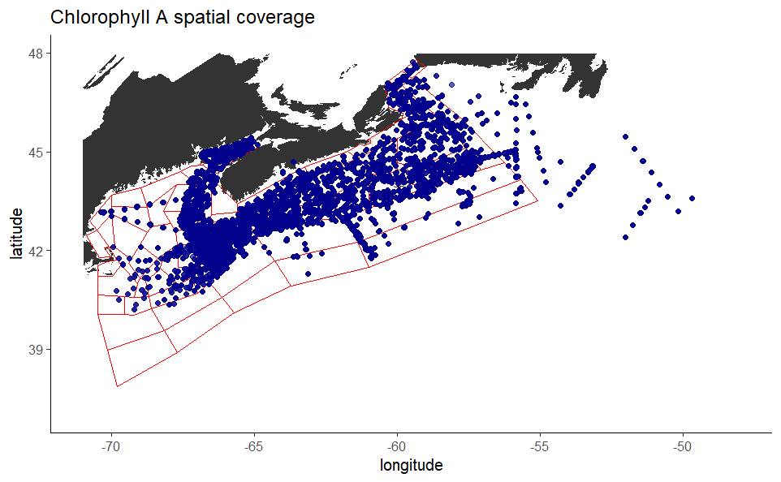

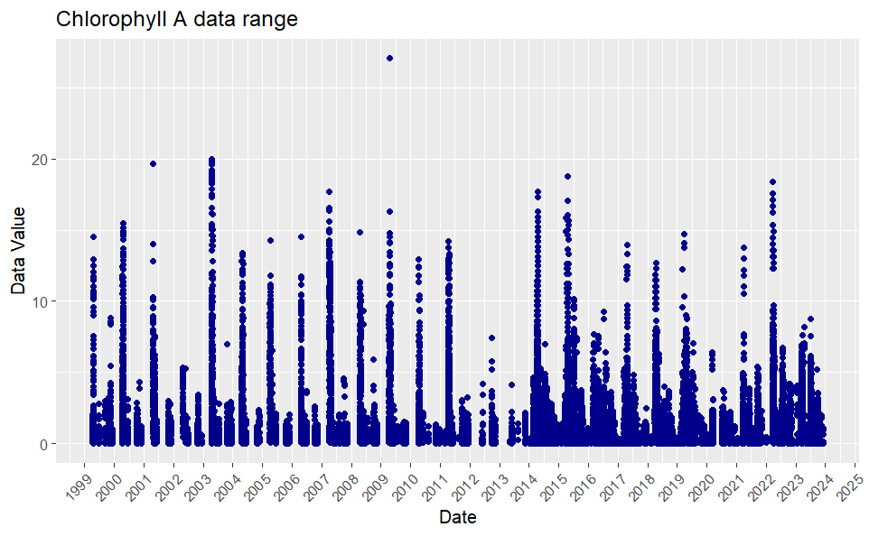

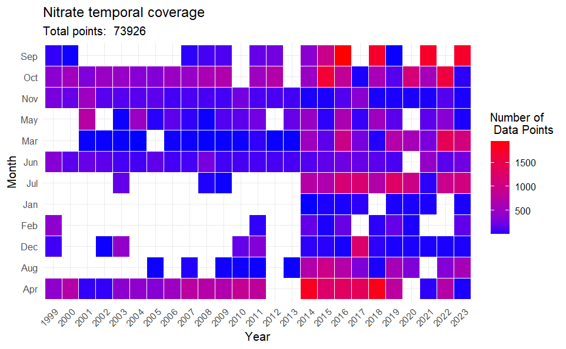

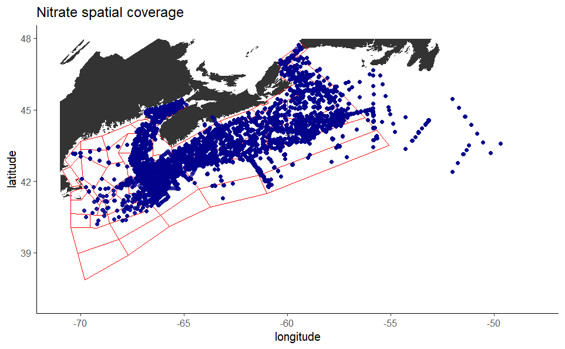

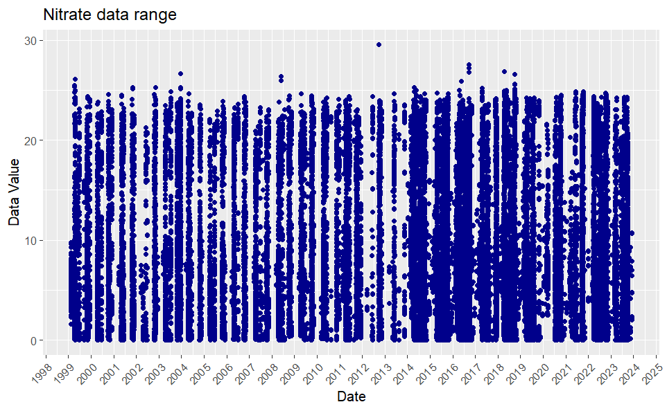

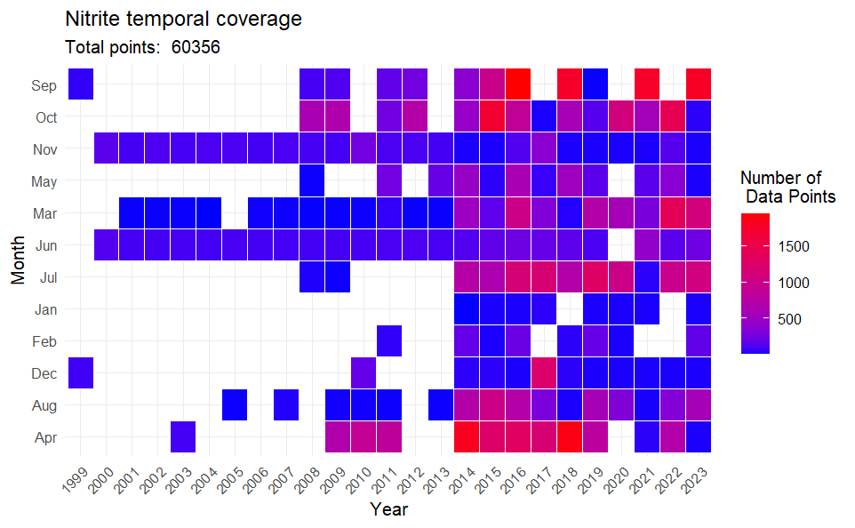

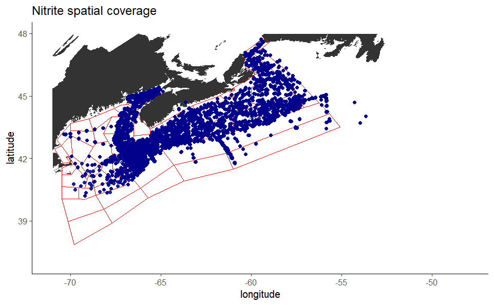

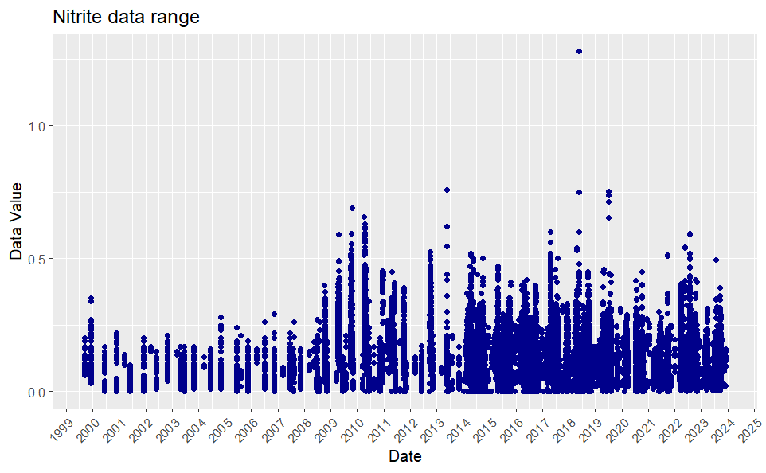

[15 more figures not shown]

```r
for (i in 1:length(data_fns)) {

  data <- read.csv(data_fns[i])

  param_name <- unique(data$PARAMETER_NAME)

  # temporal coverage by year/month ----
  yearMonth <- data %>%
    mutate(., year = format(as.Date(data$EVENT_START, '%d-%b-%y'), '%Y')) %>%
    mutate(., month = format(as.Date(data$EVENT_START, '%d-%b-%y'), '%b')) %>%
    group_by(year, month) %>%
    summarise(N = n())

  p_temp <- ggplot(yearMonth, aes(year, month)) +
    geom_tile(aes(fill = N), colour = "white") +
    scale_fill_gradient(low = "blue", high = "red") +
    labs(x = "Year", y = "Month", fill = "Number of \n Data Points") +
    theme_minimal()+
    ggtitle(paste(param_name, "temporal coverage"), subtitle = paste("Total points: ", sum(yearMonth$N)))+
    theme(axis.text.x = element_text(angle = 45, hjust = 1))

    print(p_temp)

  # spatial coverage ----


  p_sp <- ggplot(data) +
    geom_polygon(data = clwf, aes(x = longitude, y = latitude)) +
    geom_polygon(data = polygons, aes(x = Longitude, y = Latitude, group = Area), color = "red", fill = NA)+
    geom_point(aes(x = HEADER_START_LON, y = HEADER_START_LAT), colour ='darkBlue', alpha = 0.4) +
    scale_x_continuous(limits = c(-71, -48))+
    scale_y_continuous(limits = c(37, 48)) +
    theme_classic()+
    ggtitle(paste(param_name, "spatial coverage"))

  print(p_sp)

  # raw value range ----
    # TODO check units on all params

  p_range <- ggplot(data) +
    geom_point(aes(x = as.Date(EVENT_START, '%d-%b-%y'),
                   y = DATA_VALUE),
               colour = 'darkBlue') +
    scale_x_date(date_breaks = "1 year", date_labels = '%Y')+
    labs(x = 'Date', y = 'Data Value')+
    theme(axis.text.x = element_text(angle = 45, hjust = 1))+
    ggtitle(paste(param_name, "data range"))



  print(p_range)
}
```